# Analysis of Snow Crab Population Decline

Emily Nakaone, Maya Shukla, Riley Slaton, David Ta

11/15/2022

## Summary Table

| year | average_depth | average_cpue | average_bottom | average_surface | temperature_difference |
| --- | --- | --- | --- | --- | --- |
| 1975 | 89.07 | 76198.58 | 1.80 | 6.42 | 4.62 |
| 1976 | 91.70 | 42832.10 | 1.29 | 4.69 | 3.40 |
| 1977 | 89.12 | 153653.14 | 3.07 | 8.93 | 5.86 |
| 1978 | 93.71 | 31497.60 | 2.96 | 6.50 | 3.54 |
| 1979 | 85.76 | 87836.50 | 3.98 | 8.14 | 4.16 |
| 1980 | 88.26 | 49393.03 | 2.06 | 4.76 | 2.70 |
| 1981 | 91.11 | 26111.46 | 3.04 | 7.04 | 4.00 |
| 1982 | 86.91 | 24343.25 | 2.18 | 6.06 | 3.88 |
| 1983 | 90.20 | 22860.98 | 2.29 | 8.90 | 6.61 |
| 1984 | 89.84 | 16104.68 | 1.49 | 7.63 | 6.14 |
| 1985 | 88.40 | 6498.01 | 1.72 | 7.15 | 5.43 |
| 1986 | 89.30 | 16460.00 | 1.12 | 6.18 | 5.06 |
| 1987 | 90.16 | 55454.10 | 2.71 | 7.61 | 4.90 |
| 1988 | 87.49 | 41911.28 | 1.45 | 7.06 | 5.61 |
| 1989 | 87.97 | 48980.84 | 2.64 | 7.54 | 4.90 |
| 1990 | 91.67 | 41053.95 | 1.46 | 7.95 | 6.49 |
| 1991 | 93.12 | 50929.35 | 1.65 | 8.61 | 6.96 |
| 1992 | 94.05 | 37637.08 | 0.98 | 7.54 | 6.56 |
| 1993 | 89.23 | 52501.88 | 2.28 | 7.55 | 5.27 |
| 1994 | 90.17 | 59332.16 | 0.77 | 6.06 | 5.29 |
| 1995 | 89.50 | 44673.93 | 0.66 | 6.47 | 5.81 |
| 1996 | 93.22 | 30628.21 | 2.61 | 7.33 | 4.72 |
| 1997 | 91.22 | 20757.81 | 2.02 | 8.24 | 6.22 |
| 1998 | 88.56 | 14734.73 | 2.64 | 8.07 | 5.43 |
| 1999 | 87.15 | 6701.10 | 0.56 | 4.56 | 4.00 |
| 2000 | 87.30 | 11933.06 | 1.70 | 6.98 | 5.28 |
| 2001 | 88.93 | 19383.35 | 1.91 | 6.17 | 4.26 |
| 2002 | 86.96 | 8276.07 | 2.53 | 7.36 | 4.83 |
| 2003 | 90.57 | 15836.51 | 3.06 | 8.33 | 5.27 |
| 2004 | 91.62 | 28370.95 | 2.38 | 9.31 | 6.93 |
| 2005 | 88.79 | 35029.11 | 2.37 | 7.79 | 5.42 |
| 2006 | 87.72 | 18675.04 | 0.90 | 6.00 | 5.10 |
| 2007 | 89.14 | 18448.16 | 0.71 | 7.25 | 6.54 |
| 2008 | 89.46 | 13118.58 | 0.59 | 4.77 | 4.18 |
| 2009 | 89.72 | 17046.88 | 0.53 | 5.22 | 4.69 |
| 2010 | 90.88 | 41014.98 | 0.75 | 6.26 | 5.51 |
| 2011 | 92.05 | 35039.92 | 1.75 | 5.34 | 3.59 |
| 2012 | 90.47 | 29246.13 | 0.20 | 5.90 | 5.70 |
| 2013 | 92.23 | 27805.18 | 0.69 | 7.13 | 6.44 |
| 2014 | 91.47 | 30548.94 | 2.10 | 8.91 | 6.81 |
| 2015 | 91.79 | 25589.70 | 2.04 | 7.44 | 5.40 |
| 2016 | 93.23 | 34304.58 | 3.04 | 10.41 | 7.37 |
| 2017 | 93.35 | 56421.88 | 1.75 | 9.01 | 7.26 |
| 2018 | 88.35 | 78104.20 | 3.58 | 8.05 | 4.47 |

The data frame about snow crabs includes data relating to bottom temperature, surface temperature, ocean depth, and catch number. As crabs dwell on the ocean floor, looking at the bottom temperature is important. Additionally, catch size can give a good indication to snow crab populations. In 1977, the catch size was 153,653.1 and the bottom temperature that year was 3.07. However, in 1985, the catch size was 6,498.01 and the bottom temperature that year was 1.72. There is a 1.35 degree difference between the bottom temperature when catch size was the largest versus when the catch size was the smallest. Through this data, it is possible to conclude that bottom temperature affects snow crab population.

## Chart 1

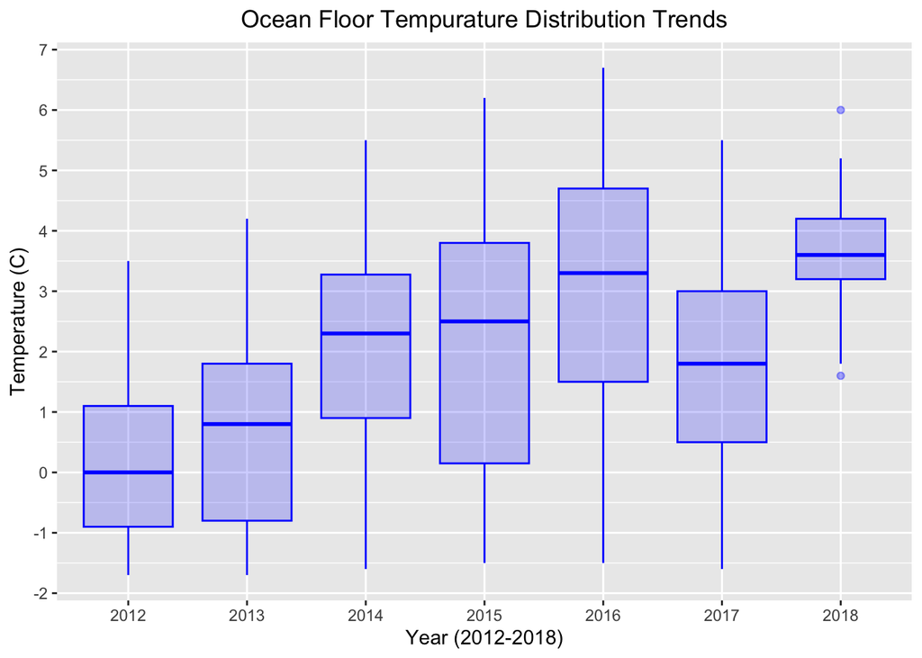

## Chart 2

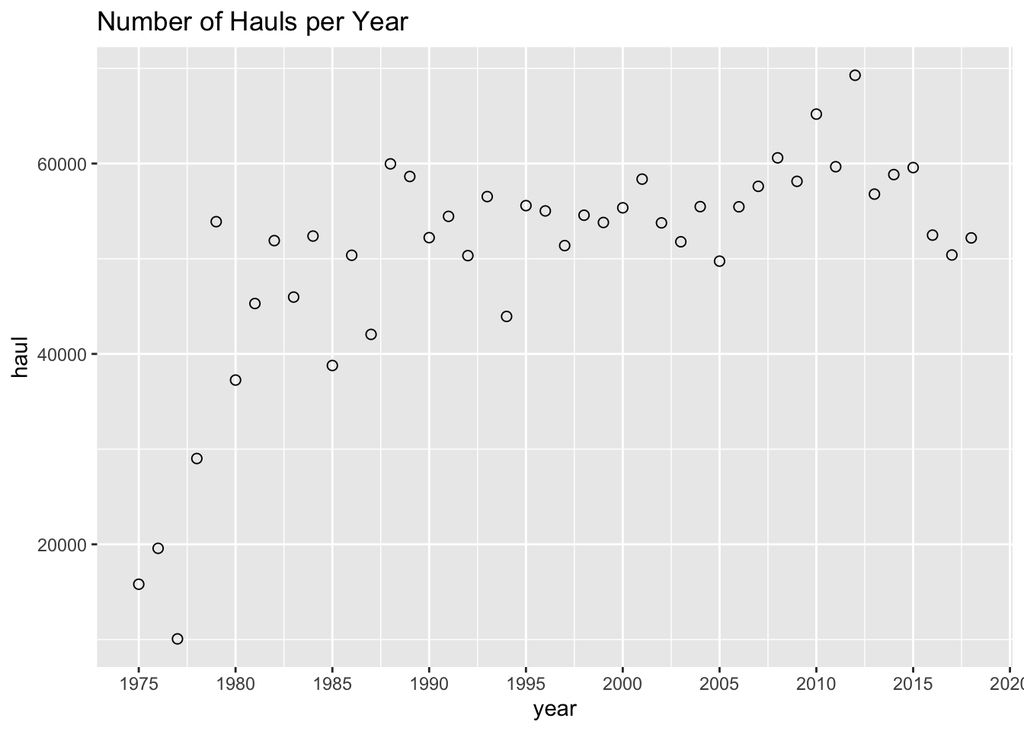

This chart depicts a scatter plot showing the trend in total hauls within a cruise across each year from 1975 through 2018. There was an increase throughout the years from 1975 through 2012 but the hauls saw a decrease after that through 2018. This graph allows us to understand how the decline in snow crab population impacts human populations who might rely on snow crabs for consumption or a means to earn.

## Chart 3

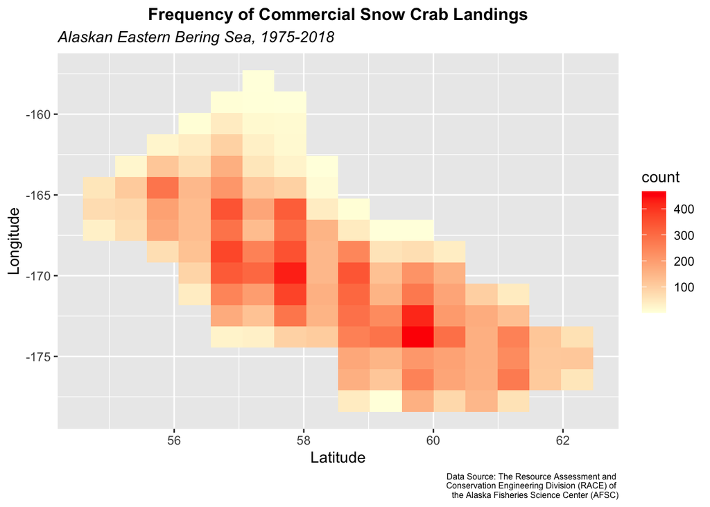

This chart’s purpose is to visualize areas of higher frequency Commercial Snow Crab Landings in the Alaskan Eastern Bering Sea region off the coast of Alaska from 1975 - 2018. The chart allows us to gain insight into geospatial aspect of our problem or specific regions of interest with respect to potential overhauling by crabbers. This allows us focus our attention and conduct further analysis on these specific, high-traffic regions of interest to gain more insight towards the proximate/ultimate cause(s) to the diminishing Snow Crab population.